# R và đồ thị

NHD

9/26/2021

# Các tạo và vẽ đồ thị ….

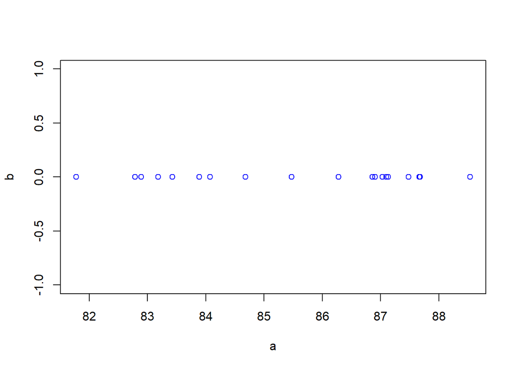

```r
a<-rnorm(20,85,2)
    b<-rep(0,20)
    plot(a,b,col="blue")
```

## Đồ thị với ggplot2

Quan điểm đồ thị gồm có **nhiều** *lớp (layers)*.

- Xác định dữ liệu (data)
- Lớp 1: xác định các biến cần vẽ: aes()
- Lớp 2: xác định loại hình cần vẽ: geom_…()
- Lớp 3: xác định màu sắc, kích cỡ,…theme_…()

```r
weightlifting <- read_excel("D:/Downloads/Sinh vien-hocky I-2021-2022/Data/weightlifting.xlsx")
    head(weightlifting)
```

```
## # A tibble: 6 x 5
    ##     Age  Body Snatch Clean Total
    ##   <dbl> <dbl>  <dbl> <dbl> <dbl>
    ## 1    26  163    210   262.  472.
    ## 2    30  141.   205   250   455
    ## 3    22  161.   208.  240   448.
    ## 4    27  118.   200   240   440
    ## 5    23  125.   195   242.  438.
    ## 6    31  140.   190   240   430
```

### Lớp 1 - khung

- Trường hợp đơn giản nhất: trong lớp 1 xác định biến x và y: **aes(x=…,y=…)**
- Có thể kết hợp với việc **tô màu** các giá trị vẽ theo các biến rời rạc aes(x=…,y=…,**fill=…**)

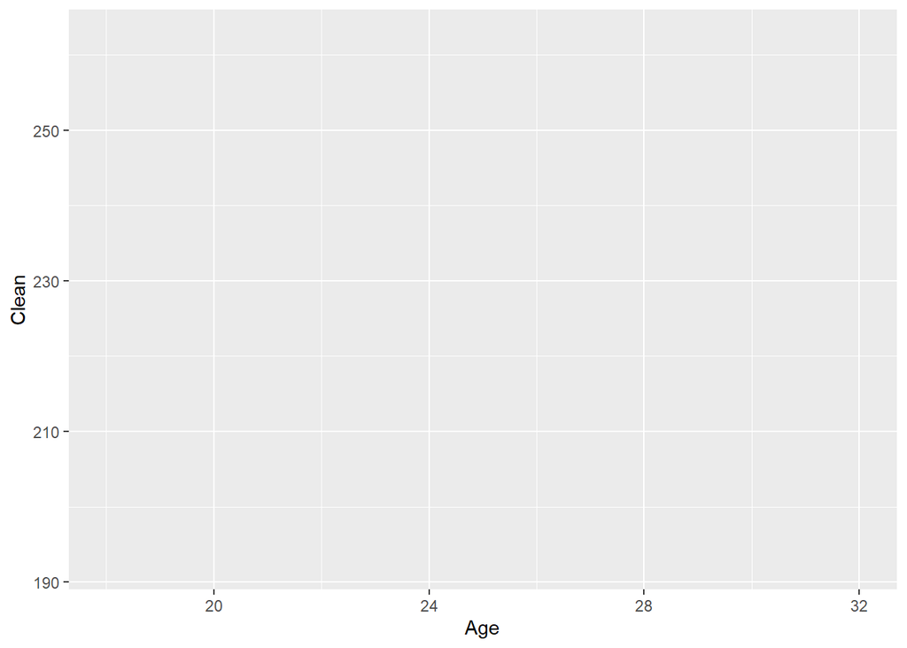

```r
ggplot(data=weightlifting,aes(x=Age,y=Clean))
```

### Lớp 2- loại đồ thị

| *Loại đồ thị* | *Ý nghĩa* |
| --- | --- |
| geom_histogram() | Biểu đồ phân bố |
| geom_boxplot() | Biểu đồ hộp |
| geom_bar() | Biểu đồ thanh |
| geom_point() | Biểu đồ điểm |
| geom_line() | Biểu đồ đường thẳng |
| geom_smooth() | Biểu đồ smooth |
| geom_density() | Biểu đồ với xác suất phân bố |
| geom_errorbar() | Biểu đồ với sai số chuẩn |

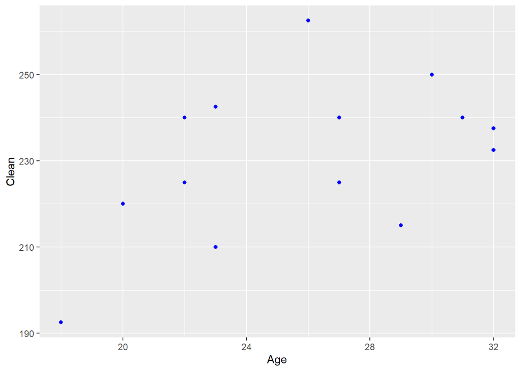

```r
ggplot(data=weightlifting,aes(x=Age,y=Clean))+
      geom_point(col="blue")
```

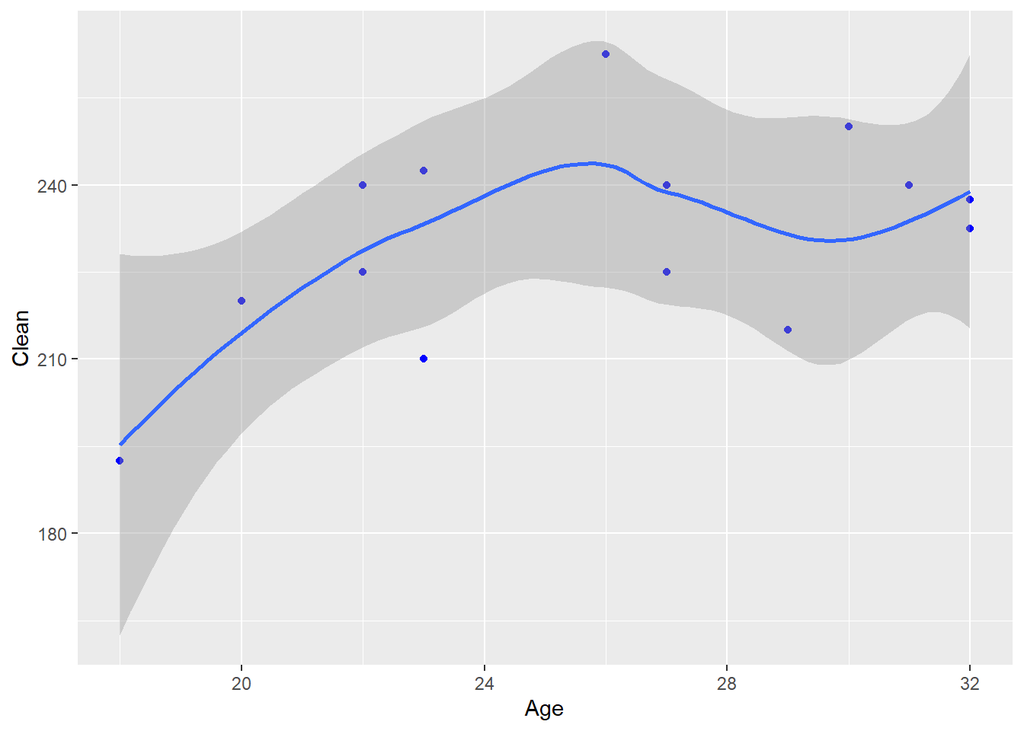

```r
ggplot(data=weightlifting,aes(x=Age,y=Clean))+
      geom_point(col="blue")+geom_smooth()
```

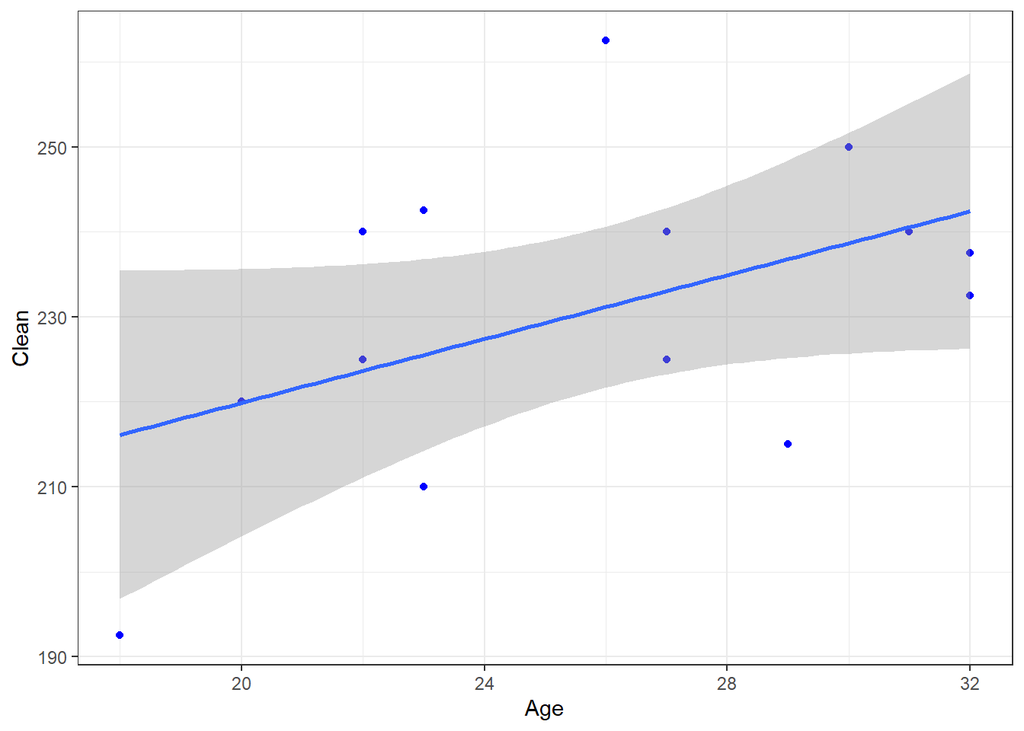

```r
ggplot(data=weightlifting,aes(x=Age,y=Clean))+
      geom_point(col="blue")+geom_smooth(method="lm")+
      theme_bw()
```

## Ví dụ biểu diễn nhiệt độ năm 2019

### Nhập dữ liệu

```r
nhietdo_2019 <- read_excel("C:/Users/ASUS/Dropbox/Bai giang/Stats2020/Thinh presentations/nhietdo_2019.xlsx")
    nhietdo_2019
```

```
## # A tibble: 15 x 13
    ##    Tinh    `1`   `2`   `3`   `4`   `5`   `6`   `7`   `8`   `9`  `10`  `11`  `12`
    ##    <chr> <dbl> <dbl> <dbl> <dbl> <dbl> <dbl> <dbl> <dbl> <dbl> <dbl> <dbl> <dbl>
    ##  1 Lai ~  14.8  18.8  20.3  23.5  24.7  24.2  23.6  24.6  22.7  21    18.6  14.2
    ##  2 Son ~  16.5  20.6  22    26    26.8  26.8  25.9  25.6  24.1  22.8  19.7  16
    ##  3 Tuyê~  17.8  22.3  22.5  27    27.6  30.1  29.7  29    27.9  25.6  22.2  18.1
    ##  4 Hà N~  18    22.4  22.6  27.5  28.2  31.6  31.4  29.9  29.5  26.7  23.5  19.6
    ##  5 Bãi ~  17.5  21.3  21.7  26.2  27.3  29.9  29.7  28.6  28.1  25.9  22.7  19.1
    ##  6 Nam ~  17.6  21.9  22    26.7  27.7  31.3  30.8  29    28.4  25.8  22.8  19.2
    ##  7 Vinh   18.8  22.9  23.2  28.2  29.7  32.8  31.8  29.6  27.9  26.2  22.7  20.1
    ##  8 Huế    20.4  24.1  25.5  28.7  29    31.1  29.9  29.6  26.8  26    23.8  21.4
    ##  9 Ðà N~  22.4  25    26.3  28    29.8  31.4  30.9  30.2  27.9  27.1  25.3  22.7
    ## 10 Qui ~  24.3  25.8  27.4  28.8  29.8  31.6  31.4  31.5  29.1  27.7  26    24.2
    ## 11 Plei~  20.4  22.6  24.2  25.6  25.2  24.5  23.3  22.8  22.6  22.9  21.2  19.7
    ## 12 Ðà L~  16.3  17.4  18.7  19.8  20.2  20.3  19.5  19.3  18.6  18.5  17.5  16
    ## 13 Nha ~  24.9  25.9  27.4  29.2  29.8  30.8  29.8  30.2  28.3  27.7  26.1  24.8
    ## 14 Vung~  26.8  27.3  28.4  30    29.9  29.3  28.3  28.2  28.2  29    27.4  26.1
    ## 15 Cà M~  27    27.4  28.6  29.9  29.5  28.5  28.2  27.6  27.9  27.9  27.8  26.5
```

### Sắp xếp lại dữ liệu

```r
nhietdo_2019_new <- pivot_longer(nhietdo_2019, 2:13, names_to = "Thang", values_to = "Nhiet_do")
    nhietdo_2019_new$Thang <- as.numeric(nhietdo_2019_new$Thang)
```

```r
filter(nhietdo_2019_new, Thang >= 6)
```

```
## # A tibble: 105 x 3
    ##    Tinh     Thang Nhiet_do
    ##    <chr>    <dbl>    <dbl>
    ##  1 Lai Châu     6     24.2
    ##  2 Lai Châu     7     23.6
    ##  3 Lai Châu     8     24.6
    ##  4 Lai Châu     9     22.7
    ##  5 Lai Châu    10     21
    ##  6 Lai Châu    11     18.6
    ##  7 Lai Châu    12     14.2
    ##  8 Son La       6     26.8
    ##  9 Son La       7     25.9
    ## 10 Son La       8     25.6
    ## # ... with 95 more rows
```

### Vẽ đồ thị đường

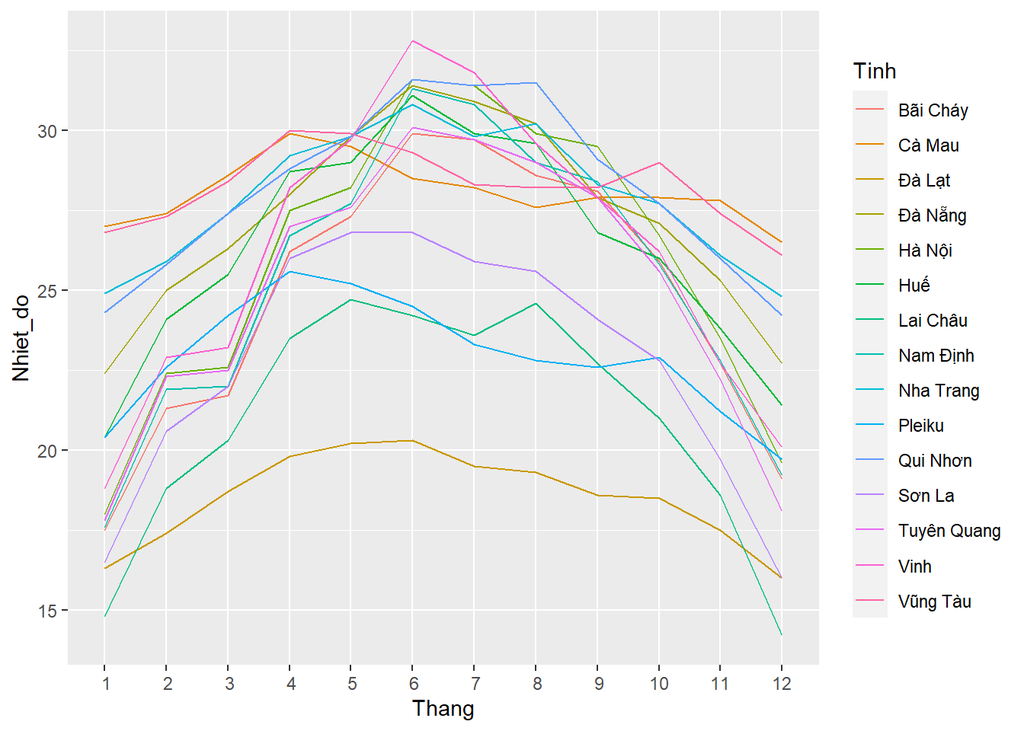

```r
ggplot(data = nhietdo_2019_new) +
      geom_line(aes(x = Thang, y = Nhiet_do, group = Tinh, color = Tinh)) +
      scale_x_discrete(limits = c(1:12))
```

```r
iris_data <- read_excel("D:/Downloads/Sinh vien-hocky I-2021-2022/Data/iris data.xlsx")
    head(iris_data)
```

```
## # A tibble: 6 x 5
    ##   S.Length S.Width P.Length P.Width Species
    ##      <dbl>   <dbl>    <dbl>   <dbl> <chr>
    ## 1      5.1     3.5      1.4     0.2 I.setosa
    ## 2      4.9     3        1.4     0.2 I.setosa
    ## 3      4.7     3.2      1.3     0.2 I.setosa
    ## 4      4.6     3.1      1.5     0.2 I.setosa
    ## 5      5       3.6      1.4     0.2 I.setosa
    ## 6      5.4     3.9      1.7     0.4 I.setosa
```

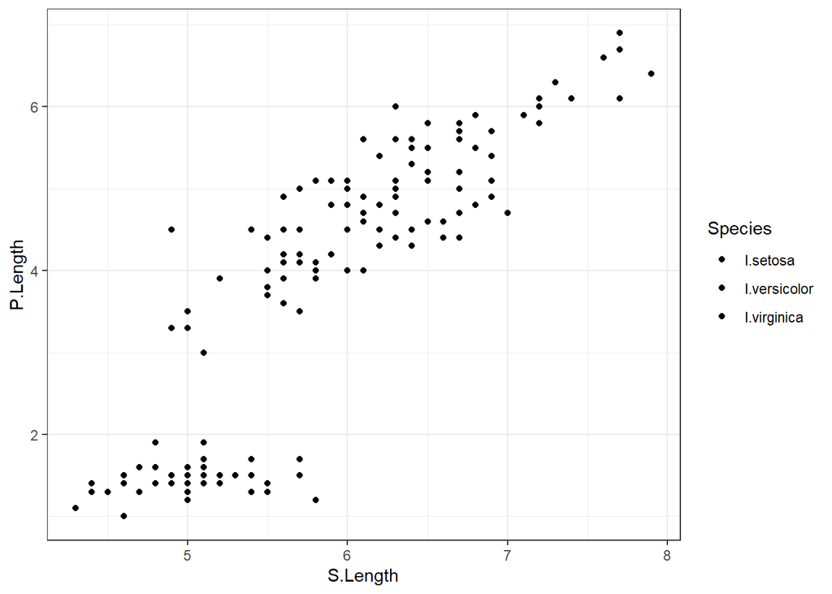

```r
ggplot(data=iris_data,aes(x=S.Length,y=P.Length,fill=Species))+
      geom_point(aes(col=Species)+geom_smooth(method="lm"))+
      theme_bw()
```

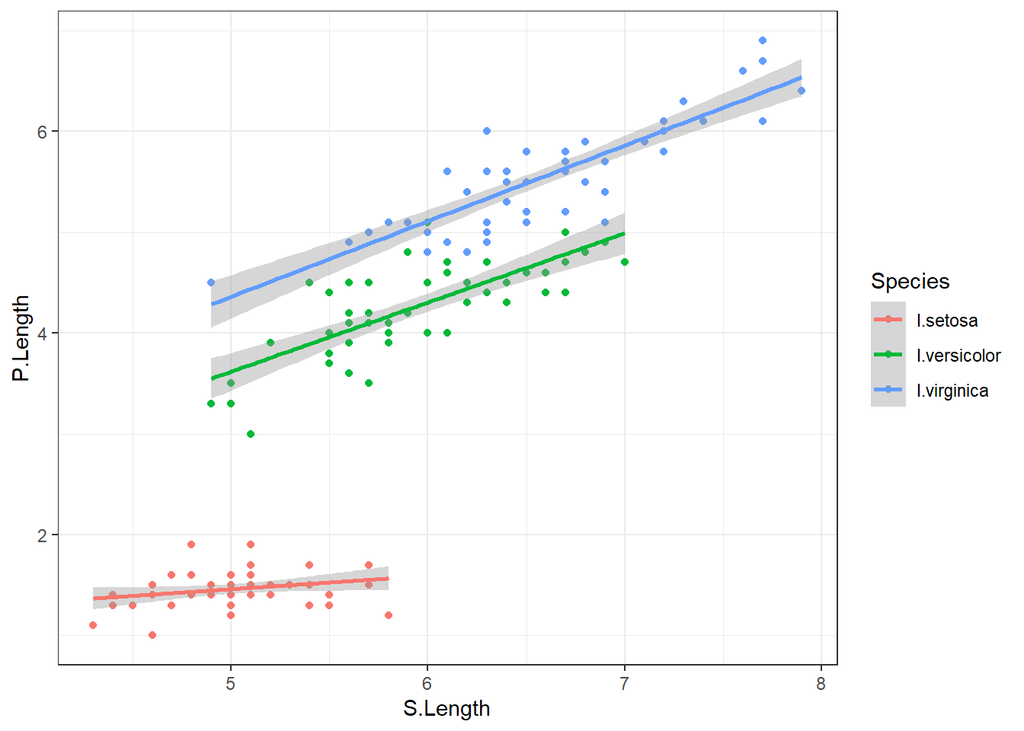

```r
ggplot(data=iris_data,aes(x=S.Length,y=P.Length,color=Species))+
      geom_point()+geom_smooth(method="lm")+
      theme_bw()
```

```r
require(ggthemes)
```

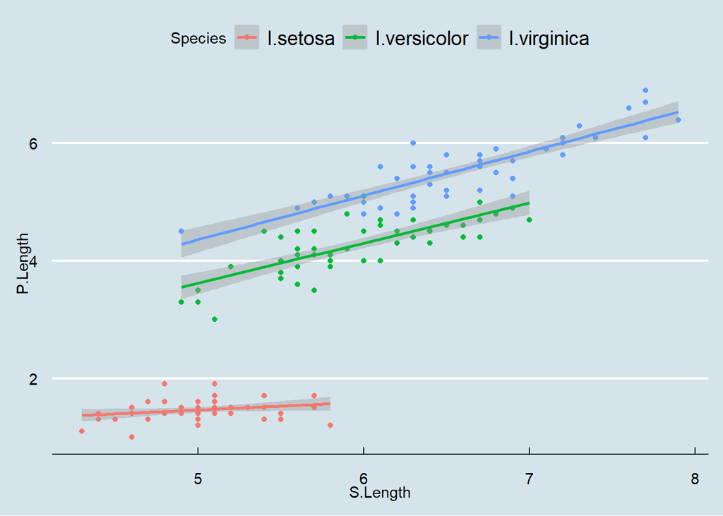

```r
ggplot(data=iris_data,aes(x=S.Length,y=P.Length,color=Species))+
      geom_point()+geom_smooth(method="lm")+
      theme_economist()
```

## Ôn tập tính toán ma trận

### Chuẩn/chiều dài/chuẩn hóa của vecto

```r
x<-c(2,1,2)
    norm(as.matrix(x),"f")
```

```
## [1] 3
```

```r
x.norm<-x/norm(as.matrix(x),"f")
```

### Các phép tính ma trận

Chuyển vị

```r
x<-matrix(c(2,1,6,5,2,1,10,3,3,20,4,10),nrow=3,ncol=4,byrow = FALSE)
    x
```

```
##      [,1] [,2] [,3] [,4]
    ## [1,]    2    5   10   20
    ## [2,]    1    2    3    4
    ## [3,]    6    1    3   10
```

```r
x.t<-t(x)
    x.t
```

```
##      [,1] [,2] [,3]
    ## [1,]    2    1    6
    ## [2,]    5    2    1
    ## [3,]   10    3    3
    ## [4,]   20    4   10
```

Cộng hai ma trận

```r
a<-matrix(c(2,1,6,5,2,1,10,3,3,20,4,10),nrow=3,ncol=4,byrow = FALSE)
    b<-matrix(c(3,2,1,4,4,2,5,6,3,6,8,5),nrow=3,ncol=4,byrow=FALSE)
    c<-a+b
    c
```

```
##      [,1] [,2] [,3] [,4]
    ## [1,]    5    9   15   26
    ## [2,]    3    6    9   12
    ## [3,]    7    3    6   15
```

Tích hai ma trận A(I,J) và B(J,K) cho kết quả là ma trận C(I,K) theo công thức

$$c_{i,k}=\sum_{i=1}^J a_{i,j} \times b_{j,k}$$

```r
A<-matrix(c(1,2,3,4,5,6),nrow = 2,ncol = 3,byrow = TRUE)
    B<-matrix(c(1,2,3,4,5,6),nrow = 3,ncol = 2,byrow = TRUE)
    C<-A%*%B
    C
```

```
##      [,1] [,2]
    ## [1,]   22   28
    ## [2,]   49   64
```

Phép tích không có tính giao hoán như phép cộng. Ngoài ra,

$$(AB)^T=B^TA^T$$

Đối với ma trận đối xứng ta có tính chất

$$AB=(BA)^T$$

### Ma trận đường chéo

```r
# tạo ma trận đường chéo 2,3
    diag(2,3)
```

```
##      [,1] [,2] [,3]
    ## [1,]    2    0    0
    ## [2,]    0    2    0
    ## [3,]    0    0    2
```

```r
# lấy giá trị đường chéo của ma trận
    A<-matrix(1:9,3,3)
    A
```

```
##      [,1] [,2] [,3]
    ## [1,]    1    4    7
    ## [2,]    2    5    8
    ## [3,]    3    6    9
```

```r
diag(A)
```

```
## [1] 1 5 9
```

```r
# thú vị này....
    diag(diag(A))
```

```
##      [,1] [,2] [,3]
    ## [1,]    1    0    0
    ## [2,]    0    5    0
    ## [3,]    0    0    9
```

Ma trận đường chéo thường được sử dụng để nhân tất cả các phần tử của một hàng hoặc cột với một số. Ví dụ:

```r
A<-matrix(c(1,2,3,4,5,6),nrow = 2,ncol = 3,byrow = TRUE)
    B<-diag(c(2,5),2)
    C<-diag(c(2,4,6),3)
    A; B;C
```

```
##      [,1] [,2] [,3]
    ## [1,]    1    2    3
    ## [2,]    4    5    6
```

```
##      [,1] [,2]
    ## [1,]    2    0
    ## [2,]    0    5
```

```
##      [,1] [,2] [,3]
    ## [1,]    2    0    0
    ## [2,]    0    4    0
    ## [3,]    0    0    6
```

```r
# tích BA
    B%*%A
```

```
##      [,1] [,2] [,3]
    ## [1,]    2    4    6
    ## [2,]   20   25   30
```

```r
# tích AC
    A%*%C
```

```
##      [,1] [,2] [,3]
    ## [1,]    2    8   18
    ## [2,]    8   20   36
```

```r
# tích BAC
    B%*%A%*%C
```

```
##      [,1] [,2] [,3]
    ## [1,]    4   16   36
    ## [2,]   40  100  180
```

Ma trận đơn vị I là ma trận đường chéo có giá trị bằng 1

```r
diag(1,3)
```

```
##      [,1] [,2] [,3]
    ## [1,]    1    0    0
    ## [2,]    0    1    0
    ## [3,]    0    0    1
```

### Tích chéo ma trận (cross-product)

```r
A<-matrix(c(1,1,2,4,3,4),nrow = 3,ncol = 2,byrow = TRUE)
    t(A)
```

```
##      [,1] [,2] [,3]
    ## [1,]    1    2    3
    ## [2,]    1    4    4
```

```r
t(A)%*%A
```

```
##      [,1] [,2]
    ## [1,]   14   21
    ## [2,]   21   33
```

```r
crossprod(A)
```

```
##      [,1] [,2]
    ## [1,]   14   21
    ## [2,]   21   33
```

Trường hợp đặc biệt của ma trận tích chéo: Phương sai/hiệp phương sai: Ma trận phương sai / hiệp phương sai thu được từ ma trận dữ liệu với ba bước: (1) trừ giá trị trung bình của mỗi cột từ mỗi phần tử của cột này (đây là “căn giữa”); (2) tính ma trận sản phẩm chéo từ ma trận căn giữa; và (3) chia mỗi phần tử của ma trận sản phẩm chéo cho số hàng của ma trận dữ liệu. Ví dụ, nếu chúng ta lấy ma trận A I = 3 x J = 2:

```r
I<-3
    J<-2
    A<-matrix(c(2,5,8,1,10,10),nrow = 3,ncol = 2,byrow = FALSE)
    A
```

```
##      [,1] [,2]
    ## [1,]    2    1
    ## [2,]    5   10
    ## [3,]    8   10
```

```r
m<-1/I*matrix(1,ncol = I)%*%A
```

Để quy tâm ma trận ta trừ đi giá trị trung bình từng cột cho mọi thành phần của cột tương ứng. Phép tính này cho biết độ lệch của từng phần tử cột so với giá trị trung bình của cột. Cách tính là:

```r
D<-A-matrix(1,nrow=3)%*%m
    D
```

```
##      [,1] [,2]
    ## [1,]   -3   -6
    ## [2,]    0    3
    ## [3,]    3    3
```

Ma trận phương sai/hiệp phương sai tính từ A theo công thức: $S=1/I*D^TD$:

```r
S<-1/I*t(D)%*%D
    S
```

```
##      [,1] [,2]
    ## [1,]    6    9
    ## [2,]    9   18
```

Phương sai nằm trên đường chéo, ngoài đường chéo là hiệp phương sai.

### Ma trận vuông nghịch đảo

$$A \times A^{-1} = I$$

```r
A<-matrix(c(1,0,0,2,1,0,1,0,1),nrow = 3, ncol = 3,byrow = FALSE)
    A
```

```
##      [,1] [,2] [,3]
    ## [1,]    1    2    1
    ## [2,]    0    1    0
    ## [3,]    0    0    1
```

```r
solve(A)
```

```
##      [,1] [,2] [,3]
    ## [1,]    1   -2   -1
    ## [2,]    0    1    0
    ## [3,]    0    0    1
```

Không phải bất kỳ ma trận vuông nào cũng có ma trận nghịch đảo của nó. Ma trận nghịch đảo sẽ không tồn tại nếu hàng (và cột) của ma trận này là phụ thuộc tuyến tính. Ví dụ:

```r
A<-matrix(c(3,1,2,4,0,1,2,2,3),nrow = 3,ncol = 3, byrow = FALSE)
    A
```

```
##      [,1] [,2] [,3]
    ## [1,]    3    4    2
    ## [2,]    1    0    2
    ## [3,]    2    1    3
```

```r
2*A[,1]-A[,3]
```

```
## [1] 4 0 1
```

```r
# solve(A)
```

Ma trận nghịch đảo được sử dụng để giải phương trình tuyến tính, và các bài toán bình phương tối thiểu trong hồi quy đa biến và phân tích phương sai.

# Các packages và function() sử dụng trong phân tích hồi quy đa biến

- `aov()`, `anova()`, và `TukeyHSD()` sử dụng trong phân tích phương sai đánh giá ảnh hưởng các biến, mức ý nghĩa phương trình hồi quy và kiểm định hậu nghiệm
- trong trường hợp của mô hình ngẫu nhiên (ramdom model), có thể sử dụng package `EMSaov` để tính lại kiểm định $F$ cho từng biến độc lập. Ví dụ đối với data antifugal `EMSanova(Y~Temperature+Carbon,type=c("R","R"),data=antifungal)`.
- `lm()`: Fitting Linear Models: `lm` is used to fit linear models. It can be used to carry out regression, single stratum analysis of variance and analysis of covariance (although `aov` may provide a more convenient interface for these).
- package `FactoMineR`: function `Regbest()` tìm mô hình tối thích. **Lưu ý** `Regbest()` chỉ sử dụng trong trường hợp các biến dự báo có dạng *liên tục*.
- `model = lm(maxO3~T12+Ne9+maxO3v,data=ozone)`; `confint(model)`: xác định khoảng tin cậy của các hệ số trong mô hình
- `predict(model,xnew,interval="pred")`: dự báo giá trị của mô hình từ `xnew`.
- `hist(residuals(model),main="Histogramme residuals",xlab="Residuals")` biểu diễn sai số của mô hình
- package `PerformanceAnalytics` và function `chart.Correlation()` biểu diễn quan hệ các biến trong mô hình.
- package `car` và function `vif()` đánh giá hiện tượng cộng tuyến

# Sử dụng các công cụ đánh giá chất lượng phương trình hồi quy

```r
ozone<- read.csv("C:/Users/ASUS/Dropbox/Bai giang/MVA2020/data/108292_ozone.txt", row.names=1, sep="")
    ozone.m<-ozone[,1:11]
```

## Data presentation

```
## Correlation matrix contains 11 numeric variables:
    ## Plotting may take very long.
```

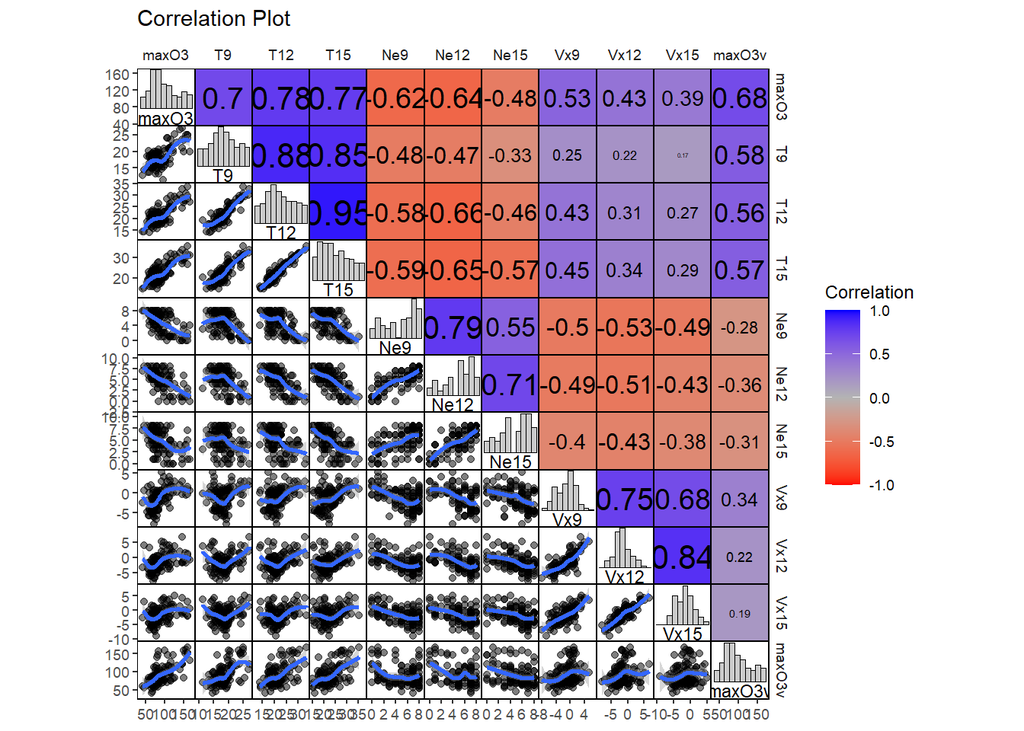

```r
ggcorrm(data = ozone[,1:11]) +
      lotri(geom_point(alpha = 0.5)) +
      lotri(geom_smooth()) +
      utri_heatmap() +
      utri_corrtext() +
      dia_names(y_pos = 0.15, size = 3) +
      dia_histogram(lower = 0.3, fill = "grey80", color = 1) +
      scale_fill_corr() +
      labs(title = "Correlation Plot")
```

```r
reg.mul <- lm(maxO3~., data=ozone.m)
    summary(reg.mul)
```

```
##
    ## Call:
    ## lm(formula = maxO3 ~ ., data = ozone.m)
    ##
    ## Residuals:
    ##     Min      1Q  Median      3Q     Max
    ## -53.566  -8.727  -0.403   7.599  39.458
    ##
    ## Coefficients:
    ##             Estimate Std. Error t value Pr(>|t|)
    ## (Intercept) 12.24442   13.47190   0.909   0.3656
    ## T9          -0.01901    1.12515  -0.017   0.9866
    ## T12          2.22115    1.43294   1.550   0.1243
    ## T15          0.55853    1.14464   0.488   0.6266
    ## Ne9         -2.18909    0.93824  -2.333   0.0216 *
    ## Ne12        -0.42102    1.36766  -0.308   0.7588
    ## Ne15         0.18373    1.00279   0.183   0.8550
    ## Vx9          0.94791    0.91228   1.039   0.3013
    ## Vx12         0.03120    1.05523   0.030   0.9765
    ## Vx15         0.41859    0.91568   0.457   0.6486
    ## maxO3v       0.35198    0.06289   5.597 1.88e-07 ***
    ## ---
    ## Signif. codes:  0 '***' 0.001 '**' 0.01 '*' 0.05 '.' 0.1 ' ' 1
    ##
    ## Residual standard error: 14.36 on 101 degrees of freedom
    ## Multiple R-squared:  0.7638, Adjusted R-squared:  0.7405
    ## F-statistic: 32.67 on 10 and 101 DF,  p-value: < 2.2e-16
```

## Cp, AIC, BIC

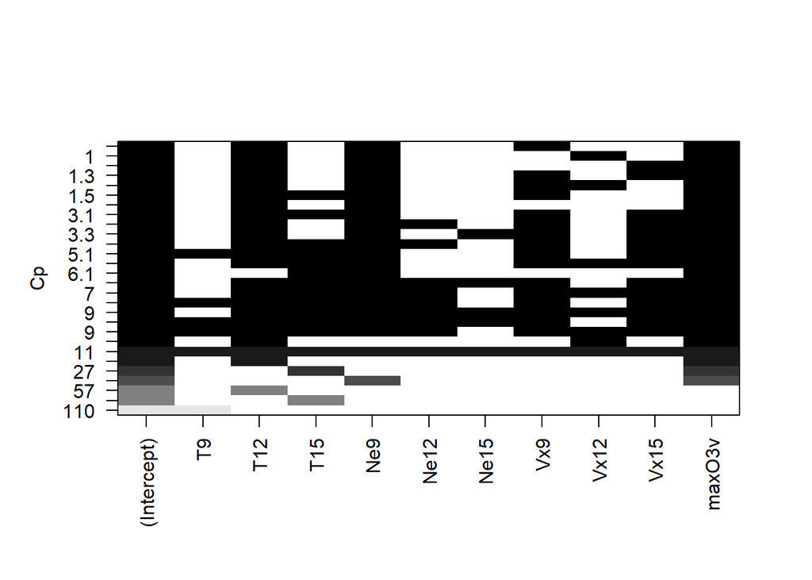

```r
choix <- regsubsets(maxO3~.,data=ozone.m,nbest=3,nvmax=11)
    plot(choix,scale="Cp")
```

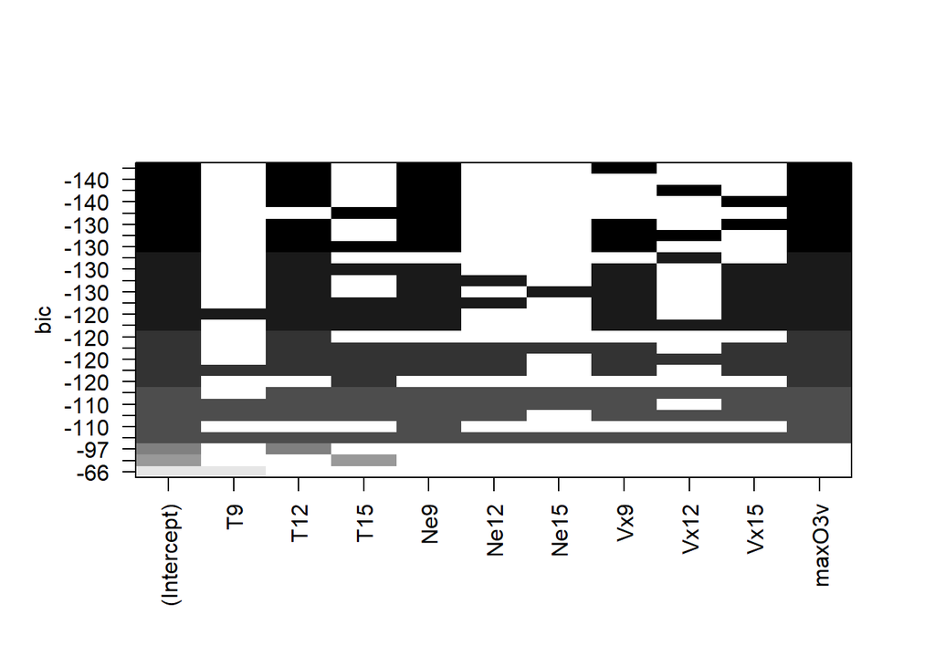

```r
plot(choix,scale="bic")
```

## Bayesian Average model

```r
reg.bma<-bicreg(ozone.m[,2:11],ozone.m[,1],strict = FALSE,OR=30)
    summary(reg.bma)
```

```
##
    ## Call:
    ## bicreg(x = ozone.m[, 2:11], y = ozone.m[, 1], strict = FALSE,     OR = 30)
    ##
    ##
    ##   27  models were selected
    ##  Best  5  models (cumulative posterior probability =  0.6454 ):
    ##
    ##            p!=0    EV       SD        model 1    model 2    model 3
    ## Intercept  100.0  11.04378  11.48063    12.6313     9.7622     8.5920
    ## T9           6.8  -0.02866   0.28175      .          .          .
    ## T12         94.2   2.64922   0.87670     2.7641     2.8531     2.8965
    ## T15         12.8   0.17580   0.62624      .          .          .
    ## Ne9        100.0  -2.64754   0.74295    -2.5154    -3.0242    -2.4425
    ## Ne12         6.4  -0.02640   0.28635      .          .          .
    ## Ne15         6.3  -0.01692   0.19285      .          .          .
    ## Vx9         35.8   0.44663   0.71010     1.2929      .          .
    ## Vx12        18.5   0.16542   0.44836      .          .         1.0104
    ## Vx15        18.2   0.15530   0.42490      .          .          .
    ## maxO3v     100.0   0.36560   0.05896     0.3548     0.3757     0.3646
    ##
    ## nVar                                       4          3          4
    ## r2                                       0.762      0.752      0.759
    ## BIC                                   -142.0039  -142.0000  -140.5578
    ## post prob                                0.210      0.210      0.102
    ##            model 4    model 5
    ## Intercept     8.3254    11.8376
    ## T9             .        -0.6937
    ## T12           2.9101     3.3019
    ## T15            .          .
    ## Ne9          -2.4839    -2.9917
    ## Ne12           .          .
    ## Ne15           .          .
    ## Vx9            .          .
    ## Vx12           .          .
    ## Vx15          0.9643      .
    ## maxO3v        0.3666     0.3850
    ##
    ## nVar            4          4
    ## r2            0.759      0.753
    ## BIC        -140.4509  -137.8384
    ## post prob     0.097      0.026
```

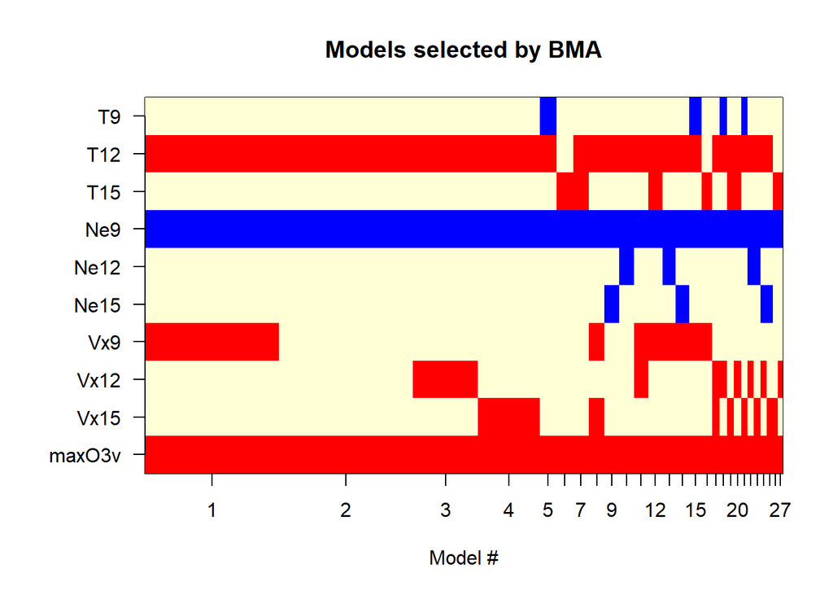

```r
imageplot.bma(reg.bma)
```

Phương pháp này có thể áp dụng được cho cả trường hợp số liệu **rời rạc, số liệu nhóm**.

## Variance decomposition methods - Relative important

http://prof.beuth-hochschule.de/groemping/?L=1 Tác giả của nhiều package phân tích thống kê như `DoE, relaimpo, preplot,`…

Chỉ số LMG giá trị trung bình $R^2$ tăng giảm tùy theo thứ tự của biến dự báo trong mô hình: A,B,C; B,A,C; C,A,B. Trong đó trung bình của $R^2$ sẽ bằng đóng góp trung bình của từng biến. Sau đó cộng lại $R^2$ cho từng biến sẽ có $R^2$ của toàn mô hình.

```r
metric=calc.relimp(reg.mul,type=c("lmg","pmvd"))
    boot =boot.relimp(reg.mul, b=1000, type=c("lmg"),fixed=F)
    booteval.relimp(boot,typesel=c("lmg"),level=0.95,bty="perc",nodiff=T)
```

```
## Response variable: maxO3
    ## Total response variance: 794.5196
    ## Analysis based on 112 observations
    ##
    ## 10 Regressors:
    ## T9 T12 T15 Ne9 Ne12 Ne15 Vx9 Vx12 Vx15 maxO3v
    ## Proportion of variance explained by model: 76.38%
    ## Metrics are not normalized (rela=FALSE).
    ##
    ## Relative importance metrics:
    ##
    ##               lmg
    ## T9     0.09780378
    ## T12    0.13039410
    ## T15    0.11976762
    ## Ne9    0.07175423
    ## Ne12   0.06840859
    ## Ne15   0.03168522
    ## Vx9    0.04862471
    ## Vx12   0.02575230
    ## Vx15   0.02216233
    ## maxO3v 0.14748846
    ##
    ## Average coefficients for different model sizes:
    ##
    ##                1X        2Xs        3Xs        4Xs        5Xs         6Xs
    ## T9      6.3129995  4.1839967  3.1079741  2.3835861  1.8293386  1.37754837
    ## T12     5.4686849  4.6188271  4.0106266  3.5394083  3.1527459  2.83015702
    ## T15     4.8187278  3.8850724  3.0871115  2.4432425  1.9264819  1.51519843
    ## Ne9    -6.7532492 -4.5313231 -3.3045655 -2.6276767 -2.2681877 -2.09546715
    ## Ne12   -7.9150343 -5.4421433 -3.8402169 -2.7986964 -2.1267813 -1.68136645
    ## Ne15   -5.7806663 -2.7941405 -1.3987475 -0.6685912 -0.2738758 -0.04986707
    ## Vx9     5.6489538  3.6753032  2.7633041  2.2483217  1.9172768  1.68274258
    ## Vx12    4.3434765  2.1903839  1.2942884  0.8526967  0.5786398  0.37391838
    ## Vx15    3.9308773  1.7781149  1.1646484  0.9284001  0.7957624  0.69711231
    ## maxO3v  0.6823463  0.5126435  0.4368646  0.3946674  0.3704098  0.35715393
    ##                7Xs         8Xs         9Xs        10Xs
    ## T9      0.98838019  0.63511204  0.30179634 -0.01901425
    ## T12     2.56591031  2.36524726  2.24247644  2.22115189
    ## T15     1.19531168  0.94916319  0.74969825  0.55853087
```

[output cut: 13 more lines]

```
    ##            percentage 0.95       0.95   0.95
    ## T9.lmg     0.0978     _BCDEF____ 0.0705 0.1323
    ## T12.lmg    0.1304     ABC_______ 0.1000 0.1647
    ## T15.lmg    0.1198     ABCD______ 0.0972 0.1475
    ## Ne9.lmg    0.0718     __CDEFGH__ 0.0395 0.1131
    ## Ne12.lmg   0.0684     ___DEFGH__ 0.0410 0.1105
    ## Ne15.lmg   0.0317     _____FGHIJ 0.0167 0.0610
    ## Vx9.lmg    0.0486     ____EFGH__ 0.0301 0.0811
    ## Vx12.lmg   0.0258     ______GHIJ 0.0134 0.0497
    ## Vx15.lmg   0.0222     _______HIJ 0.0113 0.0444
    ## maxO3v.lmg 0.1475     ABCDE_____ 0.0778 0.2160
    ##
    ## Letters indicate the ranks covered by bootstrap CIs.
    ## (Rank bootstrap confidence intervals always obtained by percentile method)
    ## CAUTION: Bootstrap confidence intervals can be somewhat liberal.
```

```r
metric
```

```
## Response variable: maxO3
    ## Total response variance: 794.5196
    ## Analysis based on 112 observations
    ##
    ## 10 Regressors:
    ## T9 T12 T15 Ne9 Ne12 Ne15 Vx9 Vx12 Vx15 maxO3v
    ## Proportion of variance explained by model: 76.38%
    ## Metrics are not normalized (rela=FALSE).
    ##
    ## Relative importance metrics:
    ##
    ##               lmg         pmvd
    ## T9     0.09780378 4.274091e-06
    ## T12    0.13039410 4.036297e-01
    ## T15    0.11976762 1.780969e-02
    ## Ne9    0.07175423 1.043030e-01
    ## Ne12   0.06840859 1.333622e-03
    ## Ne15   0.03168522 1.497947e-04
    ## Vx9    0.04862471 2.346175e-02
    ## Vx12   0.02575230 2.280315e-05
    ## Vx15   0.02216233 3.758638e-03
    ## maxO3v 0.14748846 2.093681e-01
    ##
    ## Average coefficients for different model sizes:
    ##
    ##                1X        2Xs        3Xs        4Xs        5Xs         6Xs
    ## T9      6.3129995  4.1839967  3.1079741  2.3835861  1.8293386  1.37754837
    ## T12     5.4686849  4.6188271  4.0106266  3.5394083  3.1527459  2.83015702
    ## T15     4.8187278  3.8850724  3.0871115  2.4432425  1.9264819  1.51519843
    ## Ne9    -6.7532492 -4.5313231 -3.3045655 -2.6276767 -2.2681877 -2.09546715
    ## Ne12   -7.9150343 -5.4421433 -3.8402169 -2.7986964 -2.1267813 -1.68136645
    ## Ne15   -5.7806663 -2.7941405 -1.3987475 -0.6685912 -0.2738758 -0.04986707
    ## Vx9     5.6489538  3.6753032  2.7633041  2.2483217  1.9172768  1.68274258
    ## Vx12    4.3434765  2.1903839  1.2942884  0.8526967  0.5786398  0.37391838
    ## Vx15    3.9308773  1.7781149  1.1646484  0.9284001  0.7957624  0.69711231
    ## maxO3v  0.6823463  0.5126435  0.4368646  0.3946674  0.3704098  0.35715393
    ##                7Xs         8Xs         9Xs        10Xs
    ## T9      0.98838019  0.63511204  0.30179634 -0.01901425
    ## T12     2.56591031  2.36524726  2.24247644  2.22115189
    ## T15     1.19531168  0.94916319  0.74969825  0.55853087
    ## Ne9    -2.03548014 -2.04589312 -2.10218526 -2.18909215
    ## Ne12   -1.35359614 -1.06578640 -0.76578237 -0.42101517
    ## Ne15    0.08549439  0.16778856  0.20428186  0.18373097
    ## Vx9     1.49468431  1.31960148  1.13894612  0.94790917
    ## Vx12    0.21226622  0.09517866  0.03214976  0.03119824
    ## Vx15    0.61763189  0.55188012  0.49031564  0.41859252
    ## maxO3v  0.35097501  0.34934979  0.35030733  0.35197646
```